# Regression methods - Accidents

candice

2022-11-18

## Exploratory

visualisation of the number of accidents :

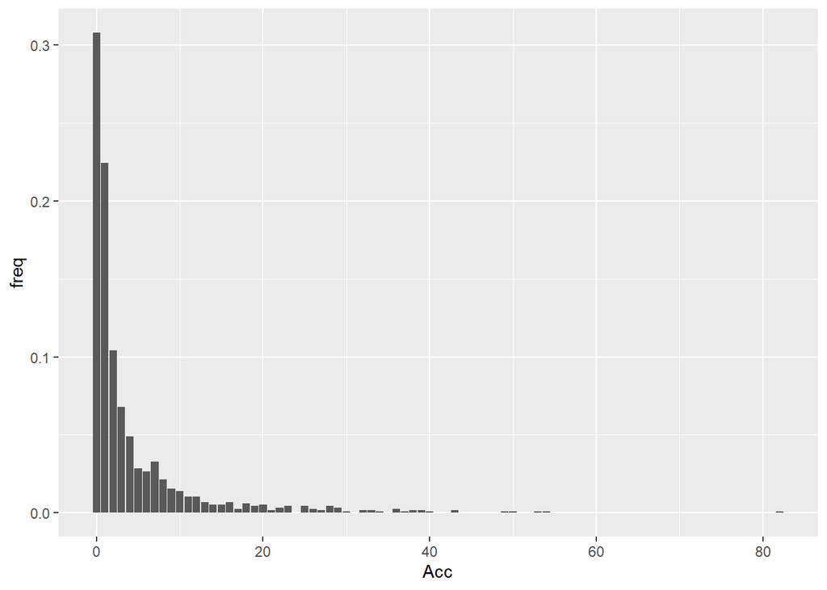

```r
Accidents %>% group_by(Acc) %>% summarise(number=n()) %>% mutate(freq = number/sum(number)) %>%
  ggplot(aes(x=Acc, y = freq)) + geom_bar(stat='identity')
```

comment : the distribution looks like an exponential/poisson distribution, there is one obvious outlier (Acc>80), and some possible outliers (at 50)

Let’s try to fit an exponential ditribution.

```
## [1] 4.176724
```

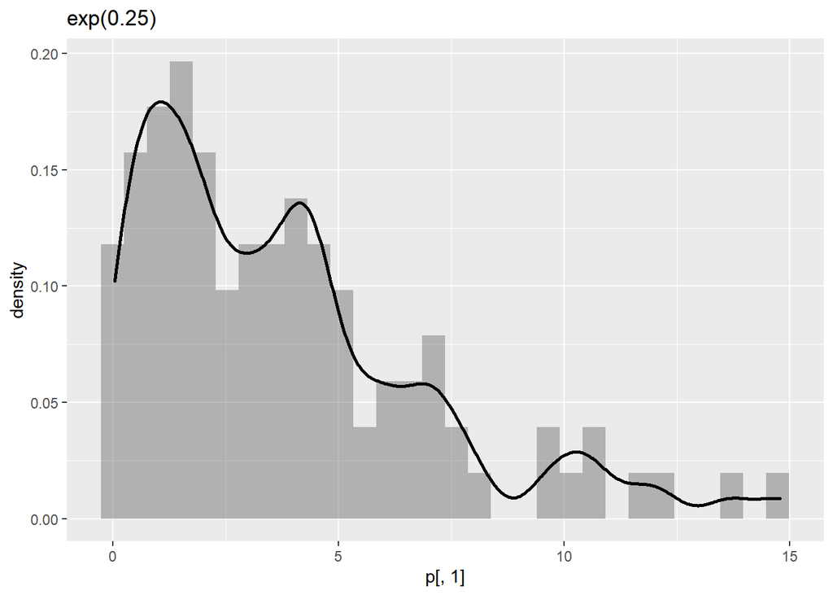

Correlations

[output not shown]

[output cut: 16 more lines]

[output not shown]

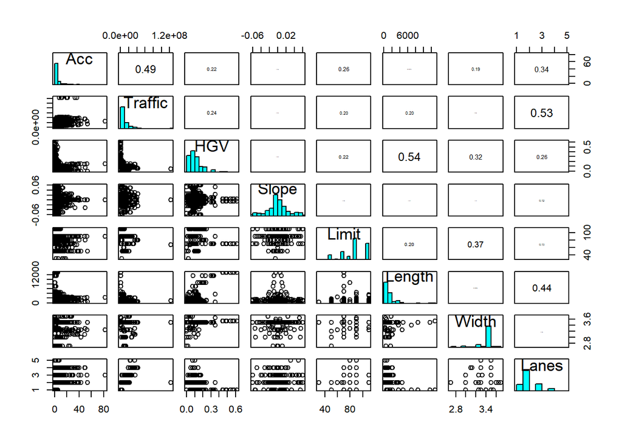

It looks like the Accidents are mostly correlated with Lanes and Traffic but also HGV and Limit. However Lanes is correlated with Length, Traffic and HGV.

Traffic vs Accidents

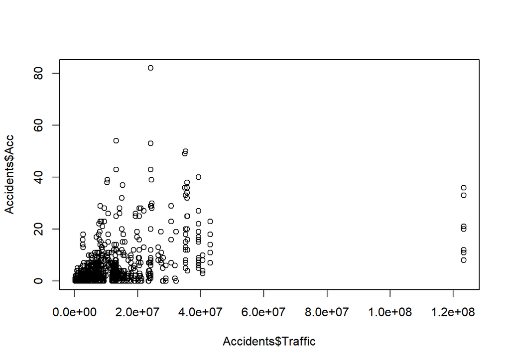

comment: some extreme values after 1.2 e+08 in Traffic and at 80 in Acc

Linear model between Traffic and Accidents. No homoscedasticity, R squared is not that good, but the coefficients are significant.

```r
lm.traffic <- lm(Acc ~ Traffic, data=Accidents)
summary(lm.traffic)
```

```
##
## Call:
## lm(formula = Acc ~ Traffic, data = Accidents)
##
## Residuals:
##     Min      1Q  Median      3Q     Max
## -28.042  -2.507  -1.596   0.275  73.757
##
## Coefficients:
##              Estimate Std. Error t value Pr(>|t|)
## (Intercept) 1.478e+00  2.395e-01   6.173 9.27e-10 ***
## Traffic     2.802e-07  1.460e-08  19.189  < 2e-16 ***
## ---
## Signif. codes:  0 '***' 0.001 '**' 0.01 '*' 0.05 '.' 0.1 ' ' 1
##
## Residual standard error: 6.602 on 1158 degrees of freedom
## Multiple R-squared:  0.2413, Adjusted R-squared:  0.2406
## F-statistic: 368.2 on 1 and 1158 DF,  p-value: < 2.2e-16
```

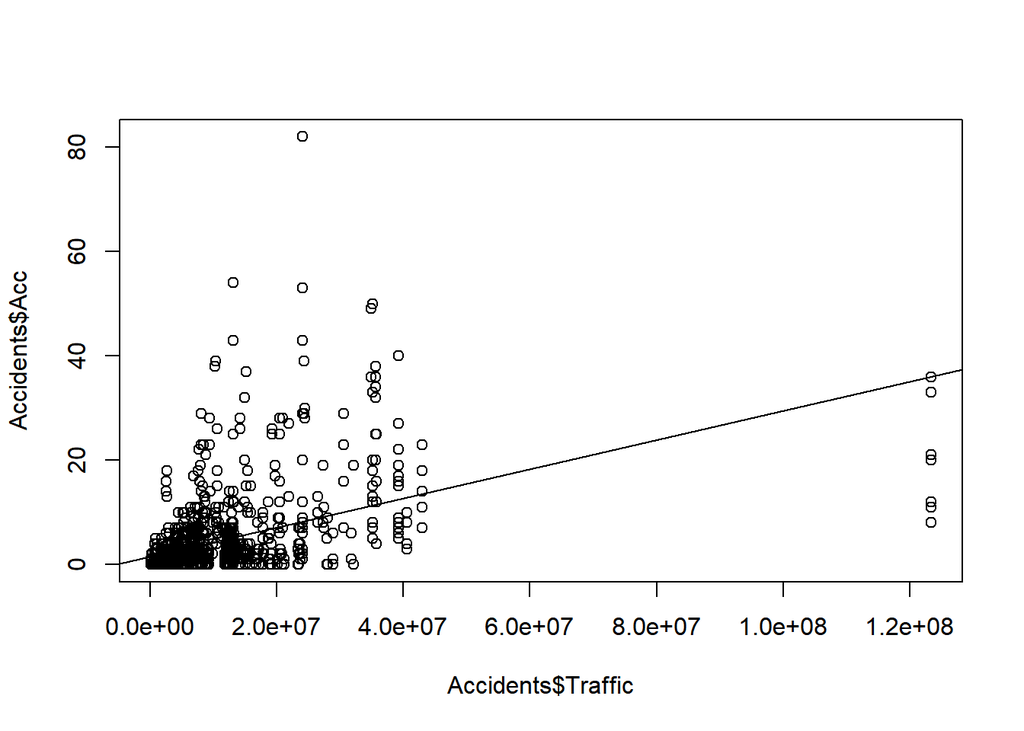

```r
plot(Accidents$Traffic, Accidents$Acc)
abline(lm.traffic)
```

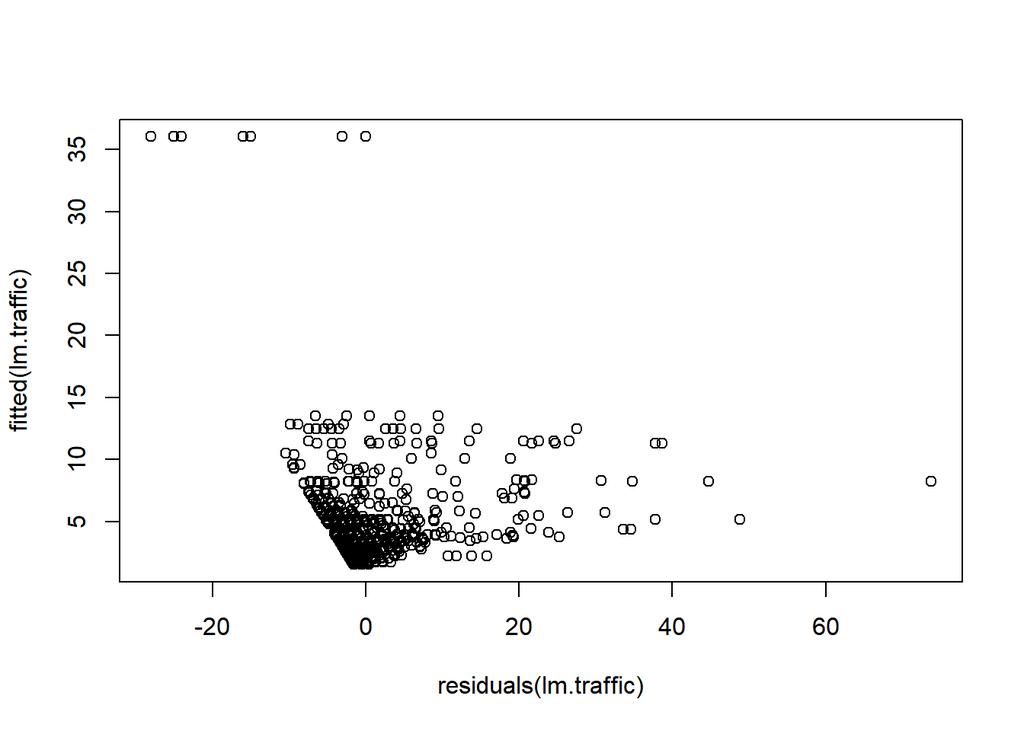

```r
plot(residuals(lm.traffic), fitted(lm.traffic))
```

Log scale may be more appropriate. When I plot, the distribution doesn’t look linear at all. The coefficients are significative but the residuals are not homoscedastic.

```r
lm.log.traffic <- lm(Acc ~ log(Traffic), data=Accidents)
summary(lm.log.traffic)
```

```
##
## Call:
## lm(formula = Acc ~ log(Traffic), data = Accidents)
##
## Residuals:
##    Min     1Q Median     3Q    Max
## -9.720 -3.402 -1.351  1.173 73.149
##
## Coefficients:
##              Estimate Std. Error t value Pr(>|t|)
## (Intercept)  -42.8780     2.5839  -16.59   <2e-16 ***
## log(Traffic)   3.0430     0.1666   18.26   <2e-16 ***
## ---
## Signif. codes:  0 '***' 0.001 '**' 0.01 '*' 0.05 '.' 0.1 ' ' 1
##
## Residual standard error: 6.678 on 1158 degrees of freedom
## Multiple R-squared:  0.2236, Adjusted R-squared:  0.223
## F-statistic: 333.5 on 1 and 1158 DF,  p-value: < 2.2e-16
```

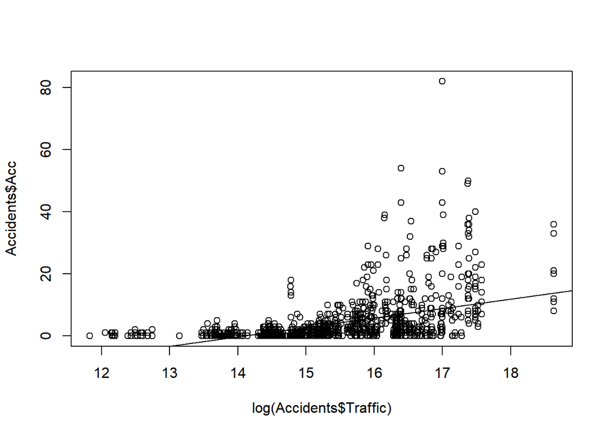

```r
plot(log(Accidents$Traffic), Accidents$Acc)
abline(lm.log.traffic)
```

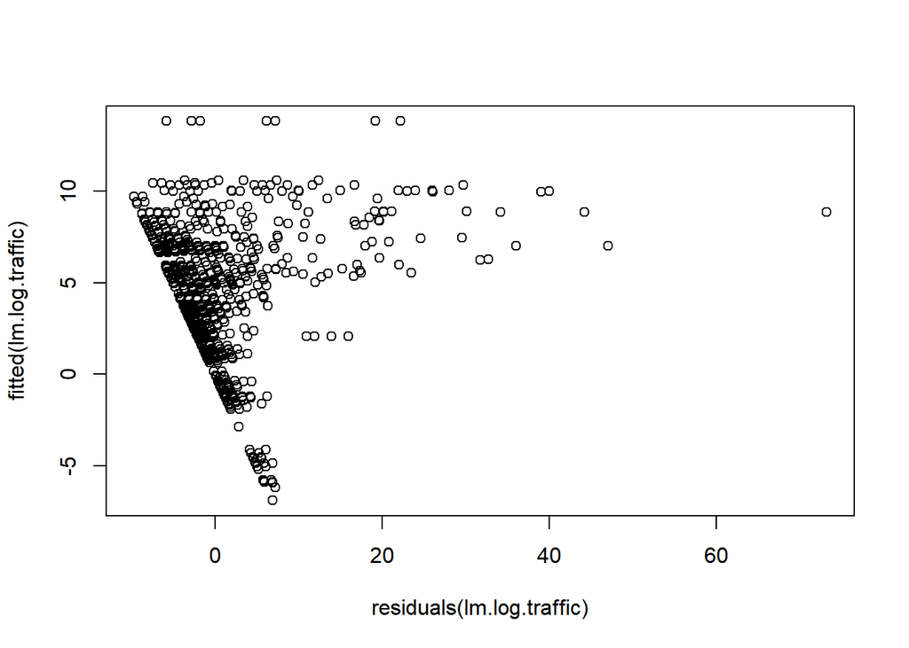

```r
plot(residuals(lm.log.traffic), fitted(lm.log.traffic))
```

Below I plot Accidents vs HGV and Accidents vs log(HGV)

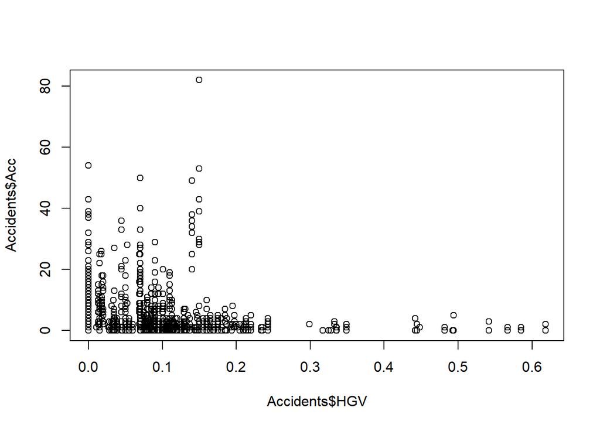

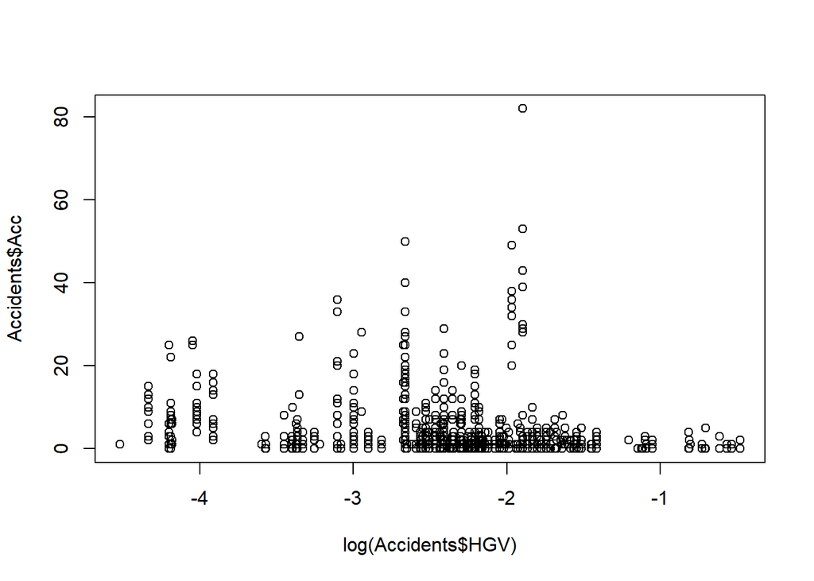

comment : some extreme values of HGV at 0.6?, looks like an exponential distribution

The linear models don’t look good neither with HGV nor with log(HGV)

```r
lm.HGV <- lm(Acc ~ HGV, data=Accidents)
summary(lm.HGV)
```

```
##
## Call:
## lm(formula = Acc ~ HGV, data = Accidents)
##
## Residuals:
##    Min     1Q Median     3Q    Max
## -6.171 -3.954 -2.192  0.707 78.527
##
## Coefficients:
##             Estimate Std. Error t value Pr(>|t|)
## (Intercept)   6.1705     0.3373  18.295  < 2e-16 ***
## HGV         -17.9849     2.3290  -7.722 2.47e-14 ***
## ---
## Signif. codes:  0 '***' 0.001 '**' 0.01 '*' 0.05 '.' 0.1 ' ' 1
##
## Residual standard error: 7.391 on 1158 degrees of freedom
## Multiple R-squared:  0.04897,    Adjusted R-squared:  0.04815
## F-statistic: 59.63 on 1 and 1158 DF,  p-value: 2.467e-14
```

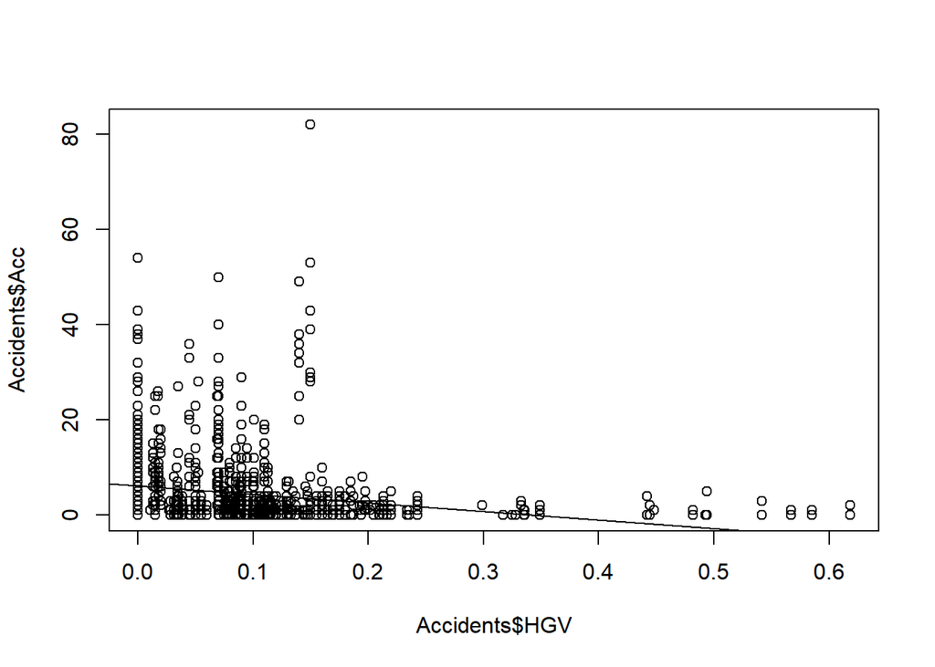

```r
plot(Accidents$HGV, Accidents$Acc)
abline(lm.HGV)
```

```r
lm.log.HGV<- lm(Acc ~ log(HGV+1), data=Accidents)
summary(lm.log.HGV)
```

```
##
## Call:
## lm(formula = Acc ~ log(HGV + 1), data = Accidents)
##
## Residuals:
##    Min     1Q Median     3Q    Max
## -6.439 -3.923 -2.109  0.624 78.663
##
## Coefficients:
##              Estimate Std. Error t value Pr(>|t|)
## (Intercept)     6.439      0.355  18.140  < 2e-16 ***
## log(HGV + 1)  -22.197      2.760  -8.044 2.14e-15 ***
## ---
## Signif. codes:  0 '***' 0.001 '**' 0.01 '*' 0.05 '.' 0.1 ' ' 1
##
## Residual standard error: 7.376 on 1158 degrees of freedom
## Multiple R-squared:  0.05292,    Adjusted R-squared:  0.0521
## F-statistic:  64.7 on 1 and 1158 DF,  p-value: 2.141e-15
```

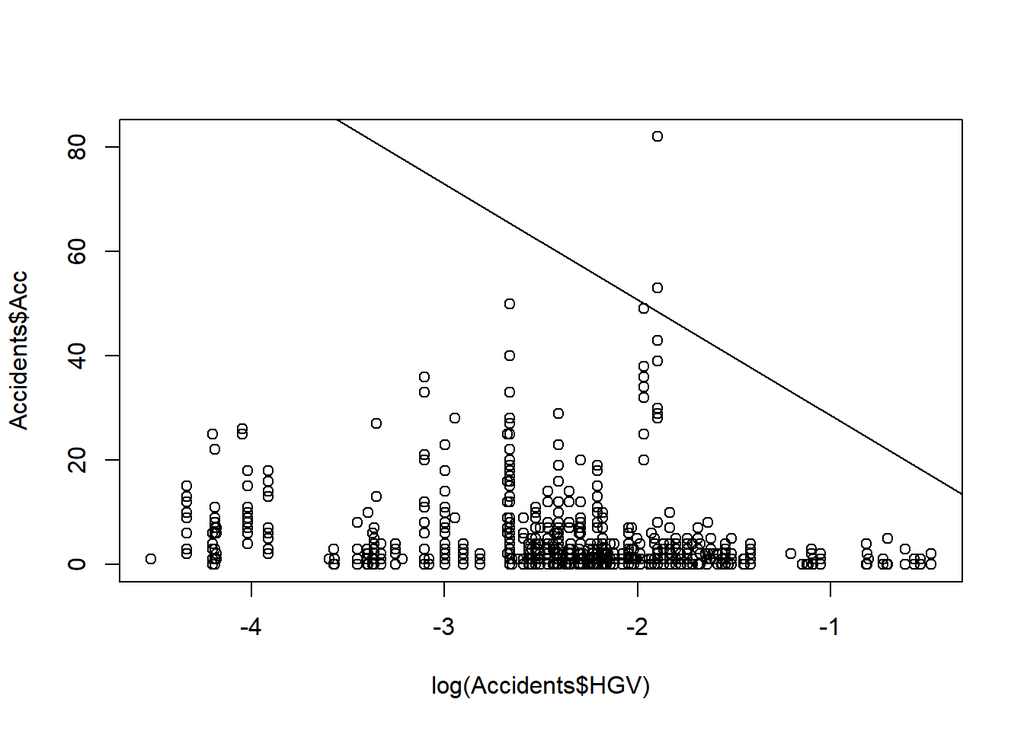

```r
plot(log(Accidents$HGV), Accidents$Acc)
abline(lm.log.HGV)
```

Some models I tried but I am not convinced

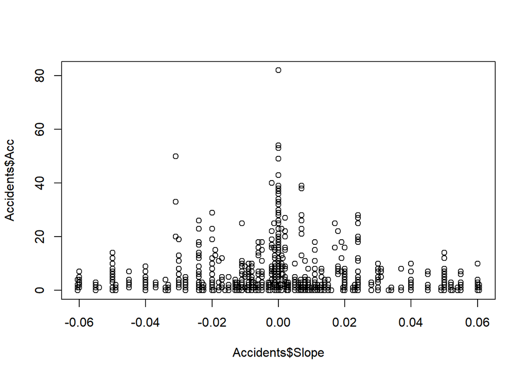

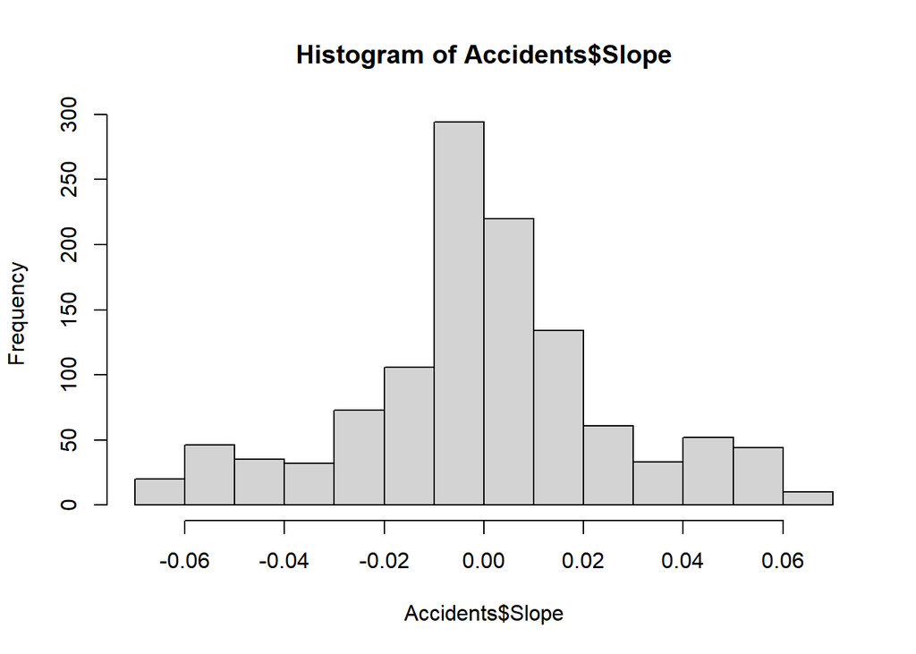

```
##
## Call:
## glm(formula = Acc ~ Slope, family = gaussian, data = Accidents)
##
## Deviance Residuals:
##    Min      1Q  Median      3Q     Max
## -4.820  -3.950  -2.948   0.142  77.814
##
## Coefficients:
##             Estimate Std. Error t value Pr(>|t|)
## (Intercept)   4.1861     0.2225  18.813   <2e-16 ***
## Slope       -10.4739     8.5630  -1.223    0.222
## ---
## Signif. codes:  0 '***' 0.001 '**' 0.01 '*' 0.05 '.' 0.1 ' ' 1
##
## (Dispersion parameter for gaussian family taken to be 57.36351)
##
##     Null deviance: 66513  on 1159  degrees of freedom
## Residual deviance: 66427  on 1158  degrees of freedom
## AIC: 7993.2
##
## Number of Fisher Scoring iterations: 2
```

```
##
## Call:
## glm(formula = (Acc + 1) ~ Length, family = Gamma, data = Accidents)
##
## Deviance Residuals:
##     Min       1Q   Median       3Q      Max
## -1.3481  -1.2653  -0.7284   0.0775   5.1304
##
## Coefficients:
##              Estimate Std. Error z value Pr(>|z|)
## (Intercept) 1.743e-01  7.151e-03  24.378  < 2e-16 ***
## Length      1.294e-05  3.449e-06   3.751 0.000176 ***
## ---
## Signif. codes:  0 '***' 0.001 '**' 0.01 '*' 0.05 '.' 0.1 ' ' 1
##
## (Dispersion parameter for Gamma family taken to be 1)
##
##     Null deviance: 1360.4  on 1159  degrees of freedom
## Residual deviance: 1342.5  on 1158  degrees of freedom
## AIC: 6137.5
##
## Number of Fisher Scoring iterations: 7
```

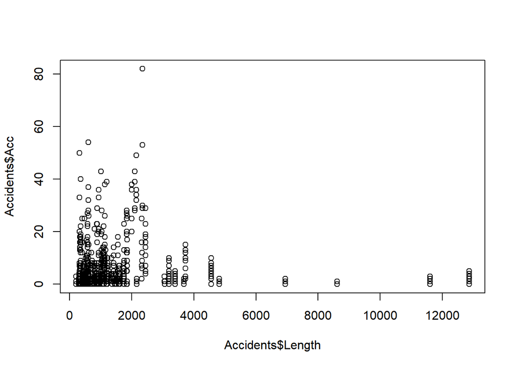

Some plots I don’t know what to do with

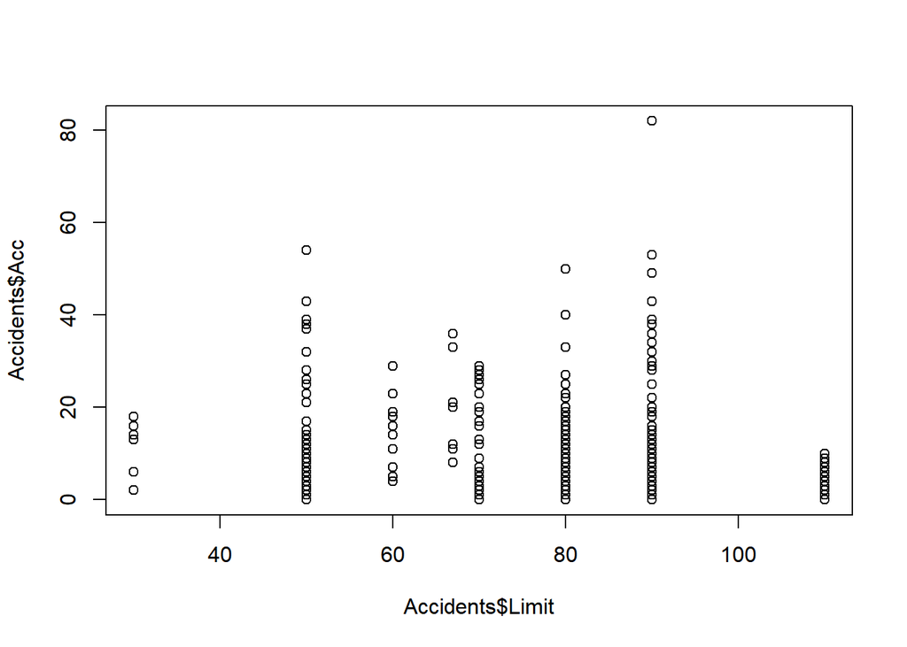

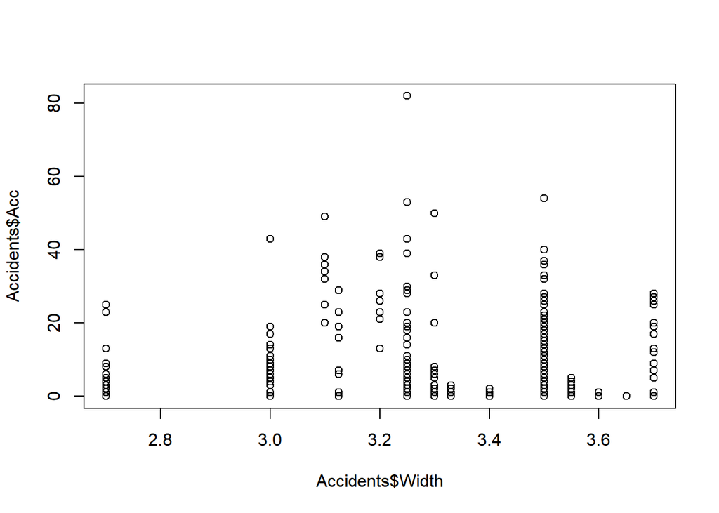

Lanes

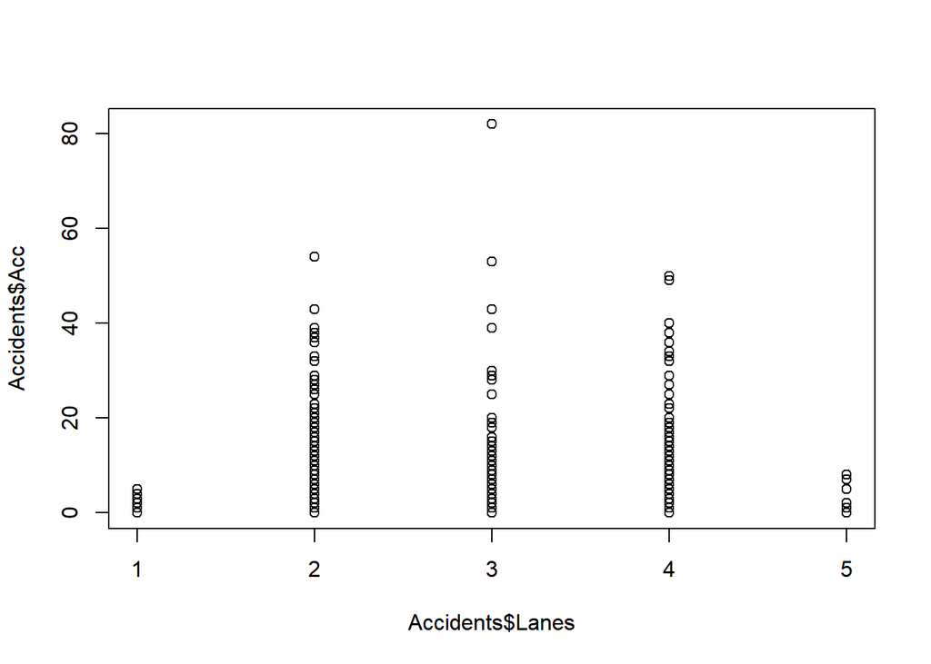

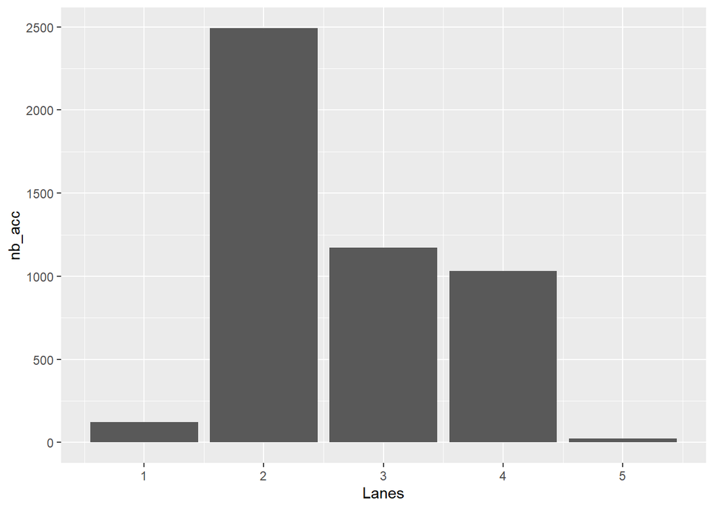

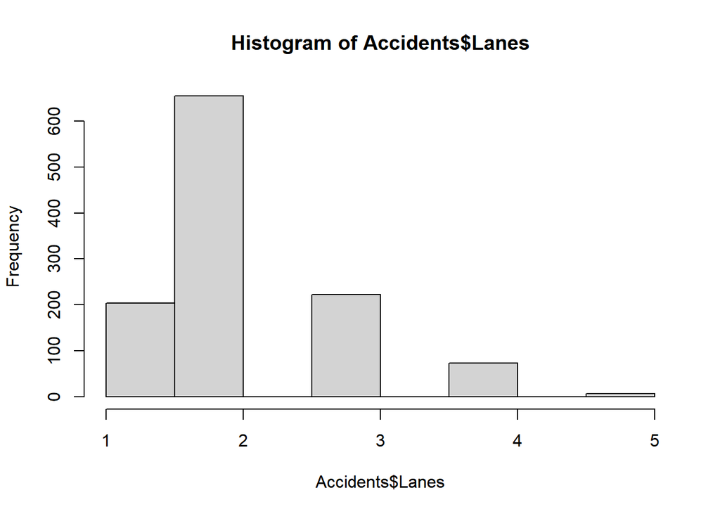

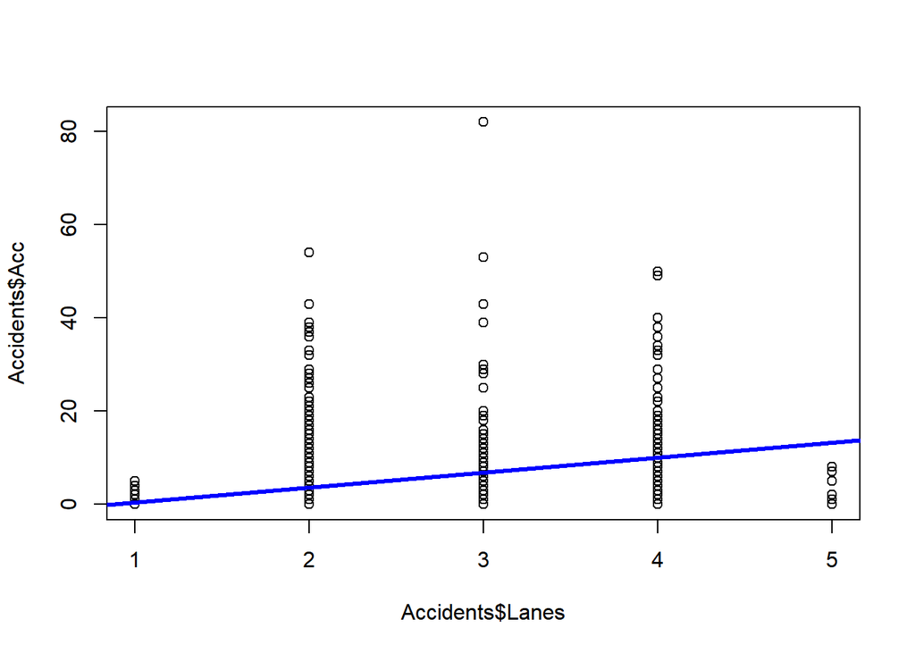

Categorical variables :

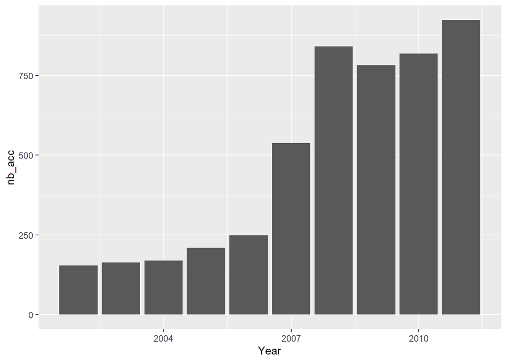

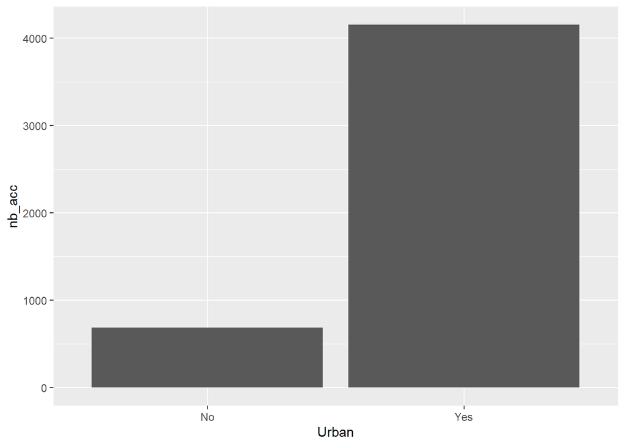

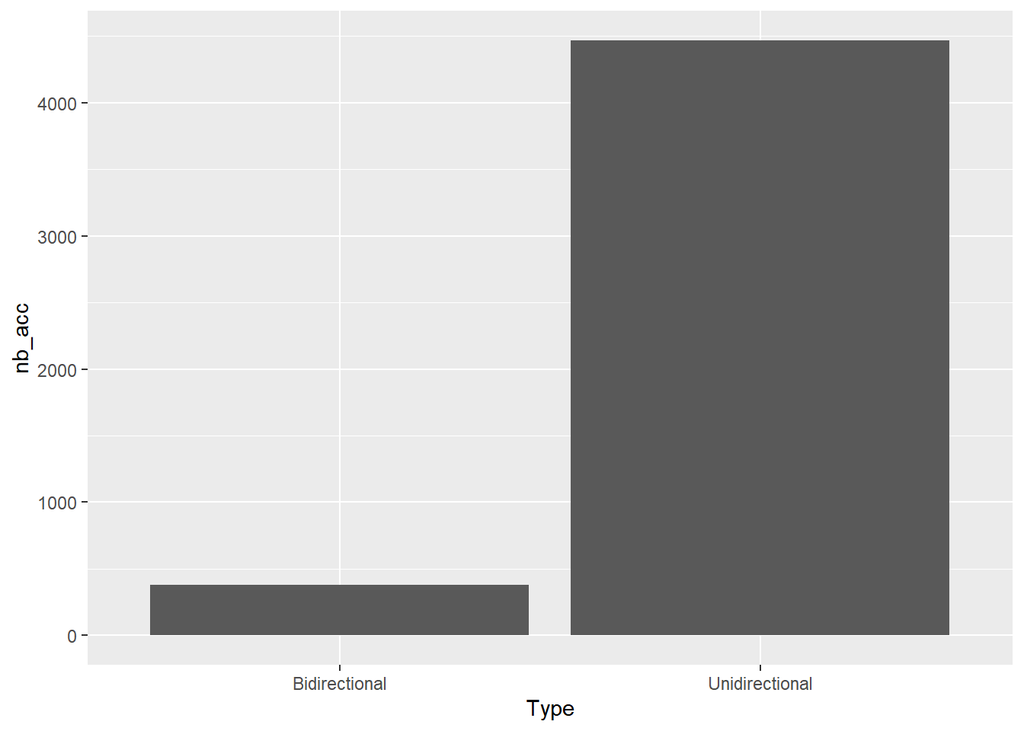

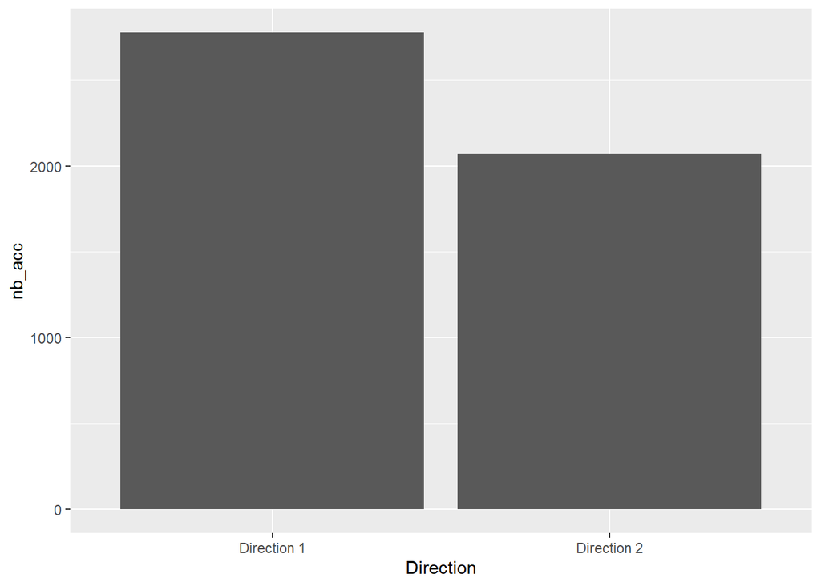

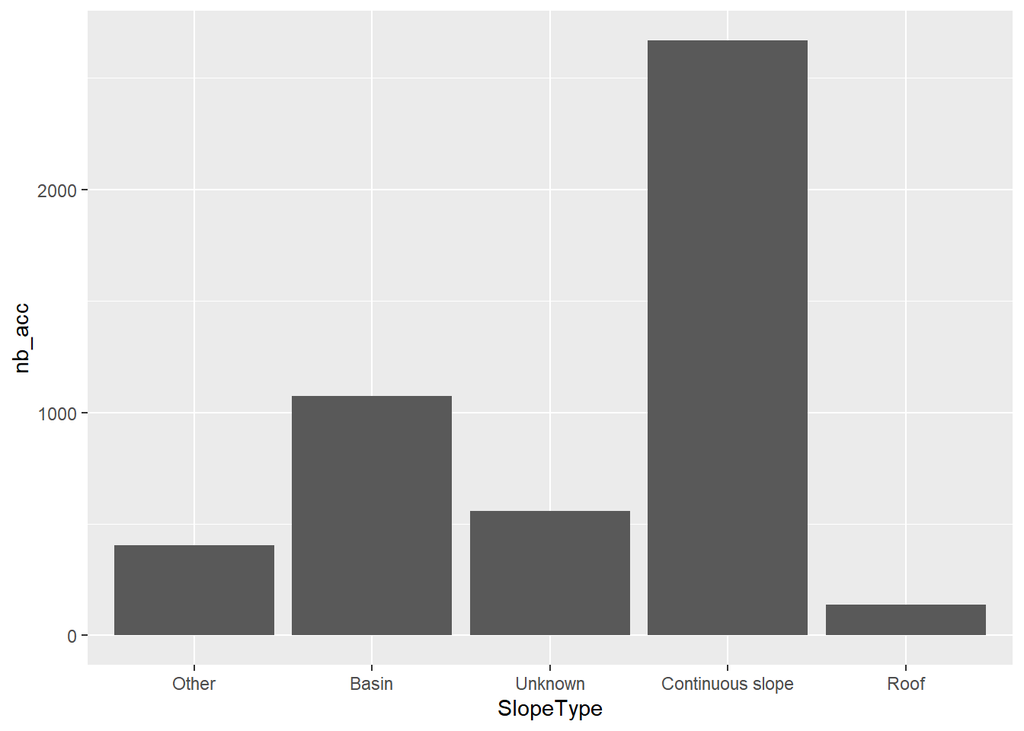

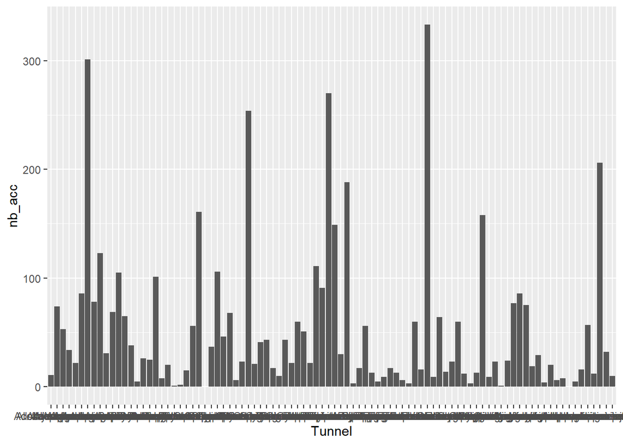

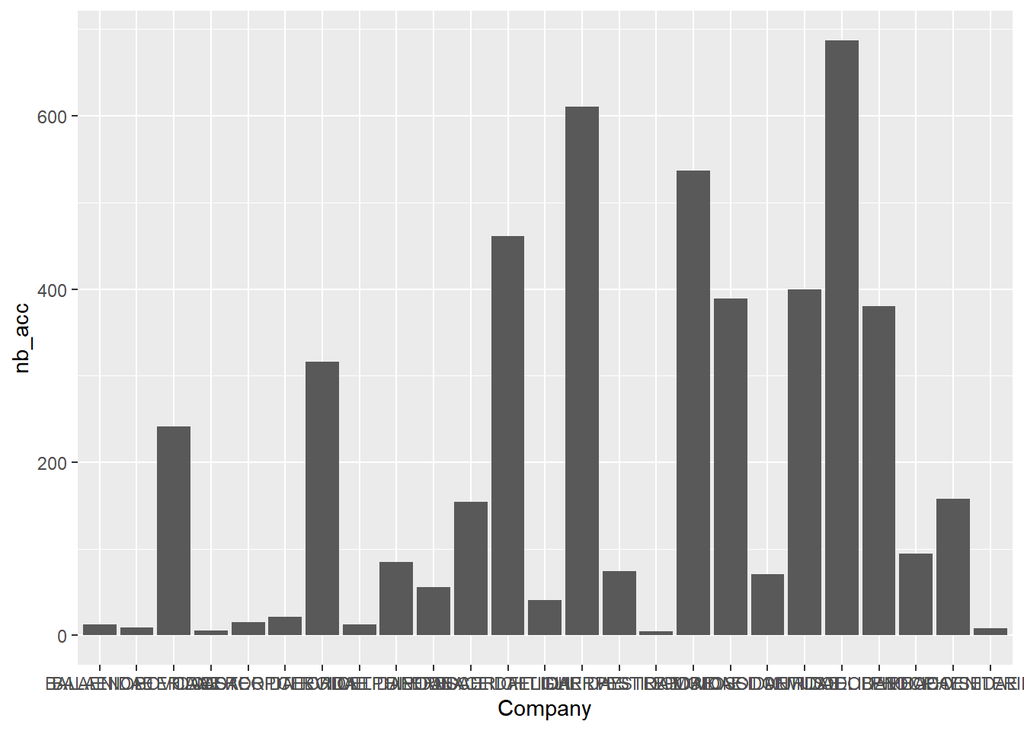

## Some first models

Linear regression with all the variables

```
##
## Call:
## lm(formula = Acc ~ ., data = Accidents)
##
## Residuals:
##     Min      1Q  Median      3Q     Max
## -23.354  -1.158  -0.232   0.910  40.042
##
## Coefficients: (32 not defined because of singularities)
##                                    Estimate Std. Error t value Pr(>|t|)
## (Intercept)                      -2.856e+02  1.113e+02  -2.566 0.010424 *
## Year                              7.867e-02  5.218e-02   1.508 0.131968
## DirectionDirection 2             -2.739e-01  2.626e-01  -1.043 0.297145
## Traffic                           1.278e-07  3.296e-07   0.388 0.698249
## HGV                               5.135e+00  8.055e+00   0.637 0.523985
## Slope                            -4.978e+00  5.279e+00  -0.943 0.345909
## UrbanYes                         -5.028e+00  2.088e+00  -2.409 0.016178 *
## TypeUnidirectional                2.301e+01  2.132e+01   1.079 0.280725
## Length                            2.927e-03  2.859e-03   1.024 0.306153
## Limit                            -1.135e-01  1.208e-01  -0.939 0.347703
## SlopeTypeBasin                    6.508e+00  5.378e+00   1.210 0.226480
## SlopeTypeUnknown                 -3.438e+00  1.199e+01  -0.287 0.774278
## SlopeTypeContinuous slope        -1.722e+01  8.511e+00  -2.023 0.043287 *
## SlopeTypeRoof                    -2.040e+01  6.010e+00  -3.394 0.000715 ***
## Width                             3.776e+01  6.851e+00   5.511 4.47e-08 ***
## Lanes                            -5.905e-01  5.986e-01  -0.986 0.324140
## TunnelAlces alces                 9.161e+00  4.644e+00   1.973 0.048785 *
## TunnelAllactaga elater            5.562e+01  1.944e+01   2.862 0.004296 **
## TunnelAllactaga major             3.705e+01  2.077e+01   1.784 0.074697 .
## TunnelAllocricetulus eversmanni   4.736e-01  5.096e+00   0.093 0.925983
## TunnelAlopex lagopus             -9.541e+00  5.959e+00  -1.601 0.109642
## TunnelApodemus agrarius           9.290e-01  2.631e+00   0.353 0.724063
## TunnelApodemus alpicola          -3.996e-01  2.747e+00  -0.145 0.884376
## TunnelApodemus epimelas           1.506e+01  3.063e+00   4.917 1.02e-06 ***
## TunnelApodemus flavicollis        2.787e+01  1.799e+01   1.549 0.121566
## TunnelApodemus mystacinus        -1.441e+01  5.612e+00  -2.568 0.010366 *
## TunnelApodemus sylvaticus        -2.085e+01  7.528e+00  -2.770 0.005704 **
## TunnelApodemus uralensis          6.145e+00  2.986e+00   2.058 0.039847 *
## TunnelApodemus witherbyi          5.319e+00  2.815e+00   1.889 0.059107 .
## TunnelArvicola amphibius          4.368e+01  1.950e+01   2.240 0.025321 *
```

[output cut: 92 more lines]

```
## CompanyLEPORIDAE                         NA         NA      NA       NA
## CompanyMOLOSSIDAE                        NA         NA      NA       NA
## CompanyMONODONTIDAE                      NA         NA      NA       NA
## CompanyMURIDAE                           NA         NA      NA       NA
## CompanyMUSTELIDAE                        NA         NA      NA       NA
## CompanyODOBENIDAE                        NA         NA      NA       NA
## CompanyPHOCIDAE                          NA         NA      NA       NA
## CompanyPHOCOENIDAE                       NA         NA      NA       NA
## CompanyPHYSETERIDAE                      NA         NA      NA       NA
## ---
## Signif. codes:  0 '***' 0.001 '**' 0.01 '*' 0.05 '.' 0.1 ' ' 1
##
## Residual standard error: 4.142 on 1061 degrees of freedom
## Multiple R-squared:  0.7263, Adjusted R-squared:  0.7011
## F-statistic: 28.74 on 98 and 1061 DF,  p-value: < 2.2e-16
```

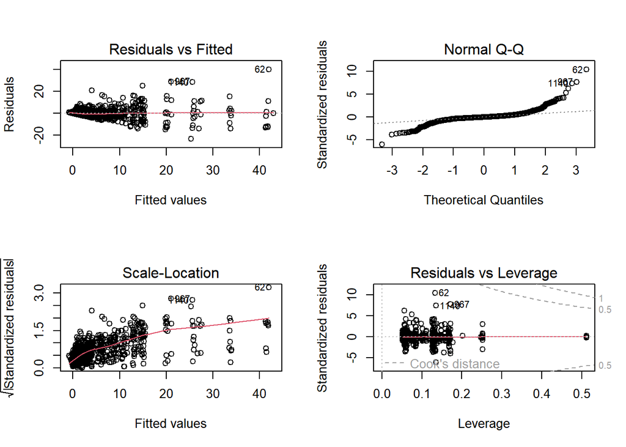

Without tunnel and company

```
##
## Call:
## lm(formula = Acc ~ Traffic + HGV + Slope + Limit + Length + Width +
##     Lanes + Direction + Urban + Type + SlopeType, data = Accidents)
##
## Residuals:
##     Min      1Q  Median      3Q     Max
## -19.094  -2.109  -0.516   1.078  62.101
##
## Coefficients:
##                             Estimate Std. Error t value Pr(>|t|)
## (Intercept)                2.395e+01  4.075e+00   5.877 5.47e-09 ***
## Traffic                    1.691e-07  1.874e-08   9.020  < 2e-16 ***
## HGV                       -2.754e+00  2.753e+00  -1.000 0.317318
## Slope                     -4.721e+00  6.536e+00  -0.722 0.470217
## Limit                     -2.990e-02  1.231e-02  -2.429 0.015281 *
## Length                     3.640e-04  1.060e-04   3.433 0.000619 ***
## Width                     -5.512e+00  1.194e+00  -4.618 4.32e-06 ***
## Lanes                      1.198e-02  3.692e-01   0.032 0.974120
## DirectionDirection 2      -3.968e-01  3.387e-01  -1.171 0.241716
## UrbanYes                   5.585e-01  5.804e-01   0.962 0.336109
## TypeUnidirectional         2.789e+00  6.800e-01   4.102 4.39e-05 ***
## SlopeTypeBasin             9.046e+00  1.432e+00   6.317 3.82e-10 ***
## SlopeTypeUnknown           3.591e+00  1.583e+00   2.269 0.023470 *
## SlopeTypeContinuous slope -3.231e+00  1.291e+00  -2.502 0.012487 *
## SlopeTypeRoof             -3.820e+00  1.389e+00  -2.751 0.006043 **
## ---
## Signif. codes:  0 '***' 0.001 '**' 0.01 '*' 0.05 '.' 0.1 ' ' 1
##
## Residual standard error: 5.64 on 1145 degrees of freedom
## Multiple R-squared:  0.4524, Adjusted R-squared:  0.4457
## F-statistic: 67.57 on 14 and 1145 DF,  p-value: < 2.2e-16
```

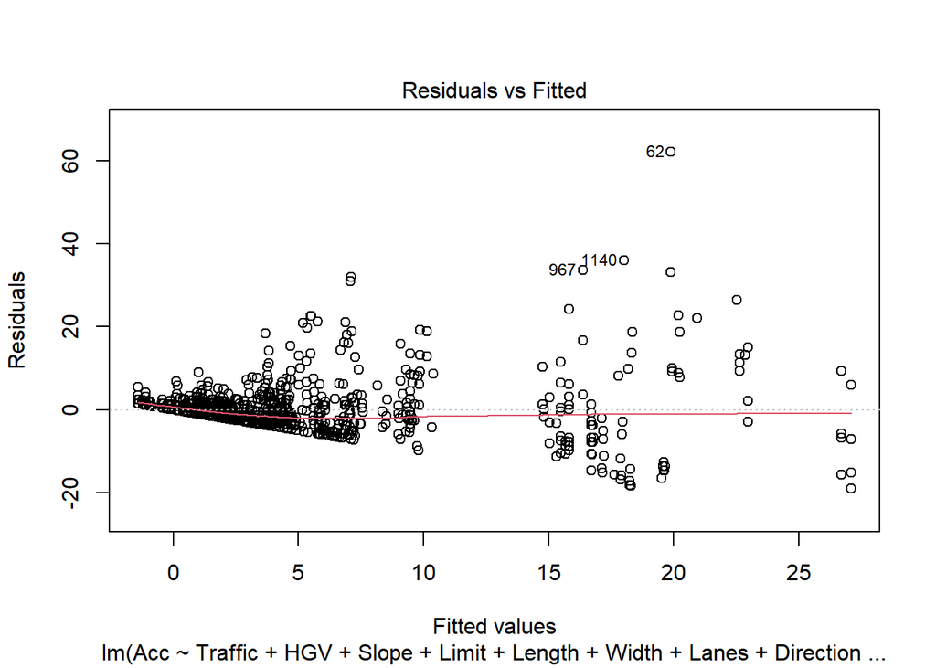